# 01-tt

2023-02-07

Step 1: Visit the TidyTuesday website and check out the resources and podcast episodes: https://www.tidytuesday.com/

Step 2: Go to the TIdyTuesday GitHub repo and read the README: https://github.com/rfordatascience/tidytuesday

Step 3: Go to the 2023 bird watching dataset and read the README and the data dictionary information: https://github.com/rfordatascience/tidytuesday/blob/master/data/2023/2023-01-10/readme.md

Step 4: Download the data set and subset using this code in R:

# Read in with tidytuesdayR package

# Install from CRAN via: install.packages(“tidytuesdayR”)

# This loads the readme and all the datasets for the week of interest

```r
#install.packages("tidytuesdayR")
```

# Either ISO-8601 date or year/week works!

tuesdata <- tidytuesdayR::tt_load(‘2023-01-10’) tuesdata <- tidytuesdayR::tt_load(2023, week = 02)

feederwatch <- tuesdata$feederwatch

```r
#tuesdata <- tidytuesdayR::tt_load(2023, week = 02)

#feederwatch <- tuesdata$feederwatch
```

# Or read in the data manually

feederwatch <- readr::read_csv(‘https://raw.githubusercontent.com/rfordatascience/tidytuesday/master/data/2023/2023-01-10/PFW_2021_public.csv’) site_data <- readr::read_csv(‘https://raw.githubusercontent.com/rfordatascience/tidytuesday/master/data/2023/2023-01-10/PFW_count_site_data_public_2021.csv’)

```r
feederwatch <- readr::read_csv('https://raw.githubusercontent.com/rfordatascience/tidytuesday/master/data/2023/2023-01-10/PFW_2021_public.csv')
site_data <- readr::read_csv('https://raw.githubusercontent.com/rfordatascience/tidytuesday/master/data/2023/2023-01-10/PFW_count_site_data_public_2021.csv')
```

# Download the raw data.

PFW_2021_public <- readr::read_csv(“https://clo-pfw-prod.s3.us-west-2.amazonaws.com/data/PFW_2021_public.csv”) dplyr::glimpse(PFW_2021_public)

```r
PFW_2021_public <- readr::read_csv("https://clo-pfw-prod.s3.us-west-2.amazonaws.com/data/PFW_2021_public.csv")
dplyr::glimpse(PFW_2021_public)
```

```
## Rows: 2,897,105
## Columns: 22
## $ loc_id             <chr> "L12782033", "L12782033", "L12782033", "L12755941",…
## $ latitude           <dbl> 44.57415, 44.57415, 44.57415, 54.13687, 54.13687, 5…
## $ longitude          <dbl> -78.20561, -78.20561, -78.20561, -108.68786, -108.6…
## $ subnational1_code  <chr> "CA-ON", "CA-ON", "CA-ON", "CA-SK", "CA-SK", "CA-SK…
## $ entry_technique    <chr> "/GOOGLE_MAP/ZOOM:15", "/GOOGLE_MAP/ZOOM:15", "/GOO…
## $ sub_id             <chr> "S79876486", "S79876486", "S79876486", "S76634904",…
## $ obs_id             <chr> "OBS1059258900", "OBS1059259256", "OBS1059259639", …
## $ Month              <dbl> 1, 1, 1, 11, 11, 11, 11, 11, 11, 11, 11, 11, 1, 1, …
## $ Day                <dbl> 24, 24, 24, 23, 23, 23, 23, 23, 23, 23, 23, 23, 20,…
## $ Year               <dbl> 2021, 2021, 2021, 2020, 2020, 2020, 2020, 2020, 202…
## $ PROJ_PERIOD_ID     <chr> "PFW_2021", "PFW_2021", "PFW_2021", "PFW_2021", "PF…
## $ species_code       <chr> "amtspa", "blujay", "bkcchi", "dowwoo", "whbnut", "…
## $ how_many           <dbl> 1, 2, 2, 2, 2, 20, 1, 2, 14, 2, 22, 20, 2, 10, 1, 2…
## $ valid              <dbl> 1, 1, 1, 1, 1, 1, 1, 1, 1, 1, 1, 1, 1, 1, 1, 1, 1, …
## $ reviewed           <dbl> 0, 0, 0, 0, 0, 1, 0, 0, 1, 0, 0, 0, 0, 0, 0, 0, 0, …
## $ day1_am            <dbl> 0, 0, 0, 0, 0, 0, 0, 0, 0, 0, 0, 0, 0, 0, 0, 0, 0, …
## $ day1_pm            <dbl> 1, 1, 1, 1, 1, 1, 1, 1, 1, 1, 1, 1, 1, 1, 1, 1, 1, …
## $ day2_am            <dbl> 0, 0, 0, 0, 0, 0, 0, 0, 0, 0, 0, 0, 0, 0, 0, 0, 0, …
## $ day2_pm            <dbl> 1, 1, 1, 1, 1, 1, 1, 1, 1, 1, 1, 1, 1, 1, 1, 1, 1, …
## $ effort_hrs_atleast <dbl> 0.001, 0.001, 0.001, 0.001, 0.001, 0.001, 0.001, 0.…
## $ snow_dep_atleast   <dbl> 5.000, 5.000, 5.000, 15.001, 15.001, 15.001, 15.001…
## $ Data_Entry_Method  <chr> "PFW Mobile App v1.1.17", "PFW Mobile App v1.1.17",…
```

# There are almost three million rows! The file is too big for github, let’s

# subsample.

set.seed(424242) PFW_2021_public_subset <- dplyr::slice_sample(PFW_2021_public, n = 1e5)

readr::write_csv(PFW_2021_public_subset, here::here(“data”, “2023”, “2023-01-10”, “PFW_2021_public.csv”))

```r
set.seed(424242)
PFW_2021_public_subset <- dplyr::slice_sample(PFW_2021_public, n = 1e5)

readr::write_csv(PFW_2021_public_subset, here::here("misc", "data", "PFW_2021_public.csv"))
```

Step 5: Now that you know what types of data are available, write down 2-3 questions you want to answer using this dataset (e.g., how does the number of birds sited relate to the habitat type?)

how many birds based on place date type of bird

```r
library(tidyverse)
PFW_2021_public_subset %>%
  group_by(subnational1_code, Month, species_code) %>%
  summarize(total_count = sum(how_many, na.rm=TRUE)) %>%
  filter(total_count > 500)
```

```
## # A tibble: 37 × 4
## # Groups:   subnational1_code, Month [17]
##    subnational1_code Month species_code total_count
##    <chr>             <dbl> <chr>              <dbl>
##  1 CA-BC                 1 pinsis               607
##  2 CA-ON                 1 amegfi               549
##  3 CA-ON                 1 bkcchi               668
##  4 CA-ON                 1 blujay               529
##  5 CA-ON                 1 comred              1085
##  6 CA-ON                 1 daejun               729
##  7 CA-ON                 1 houspa              1018
##  8 CA-ON                 1 moudov               942
##  9 CA-ON                 2 amegfi               739
## 10 CA-ON                 2 bkcchi               549
## # … with 27 more rows
```

```r
df <- PFW_2021_public_subset %>%
  group_by(subnational1_code, Month, species_code) %>%
  summarize(total_count = sum(how_many, na.rm=TRUE)) %>%
  filter(total_count > 500)
```

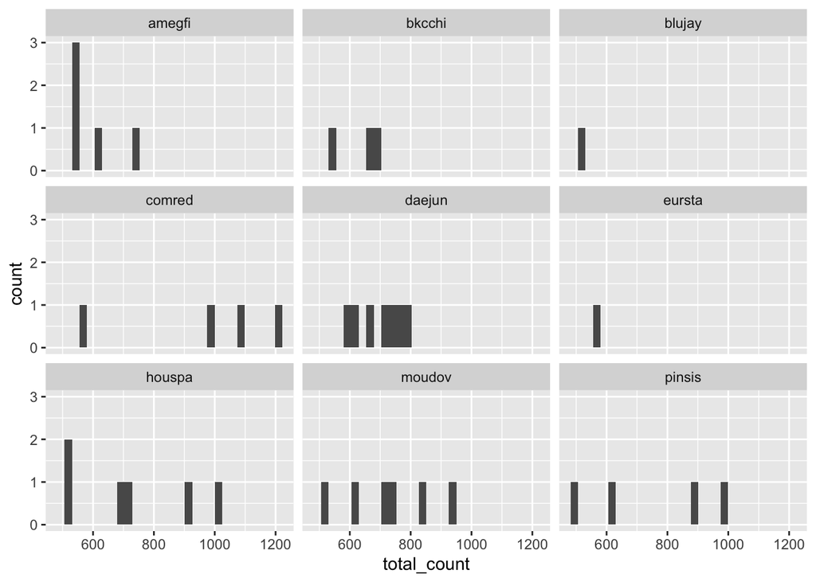

```r
ggplot(df, aes(x = total_count)) +
  geom_histogram() +
  facet_wrap(~species_code)
```

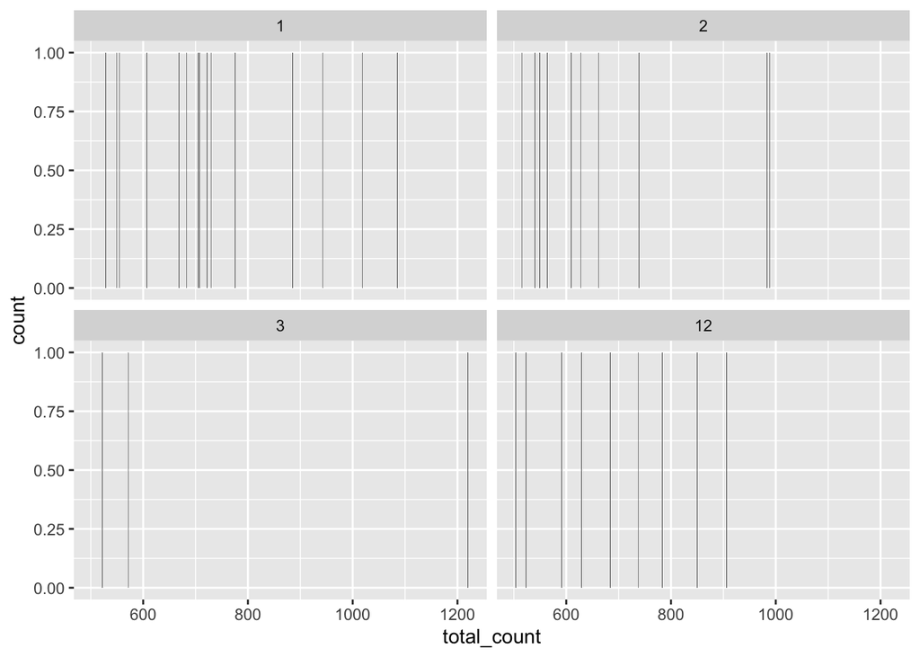

```r
ggplot(df, aes(x = total_count)) +
  geom_bar() +
  facet_wrap(~Month)
```

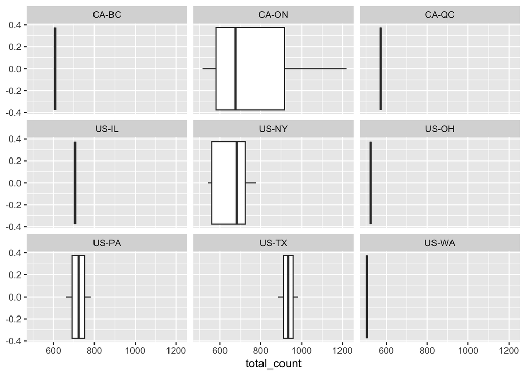

```r
ggplot(df, aes(x = total_count)) +
  geom_boxplot() +
  facet_wrap(~subnational1_code)
```

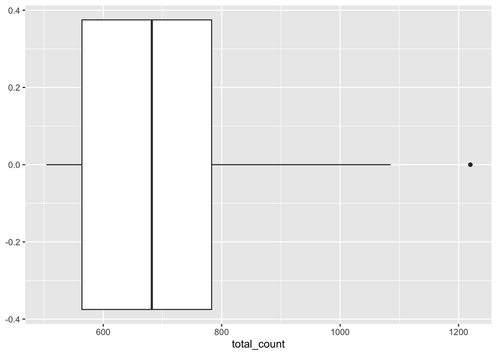

```r
ggplot(df, aes(x = total_count)) +
  geom_boxplot()
```